# Activity Performance Prediction

Bach

13 April 2019

# 1. Overview

In this report, we use data from accelerometers on the belt, forearm, arm, and dumbell of 6 participants to predict the manner in which they did the exercise. The data come from [Groupware@LES](http://groupware.les.inf.puc-rio.br/har). The participants were asked to perform barbell lifts correctly and incorrectly in 5 different ways. Based on the data collected, we use trees and boosting technics to predict the manner in which they did the exercise. We find that boosting model is more accurate compare to tree model.

# 2. Loading and processing the raw data

## *2.1 Library used*

## *2.2 Download training and testing data*

```r
training <- read.csv("./Fitbit/training.csv")
testing <- read.csv("./Fitbit/testing.csv")
```

## *2.3. Data preprocessing*

First, we remove columns with NA by using test data as referal for NA. In fact, when we look at the testing data, we remark that some covariates have NA. So we decide to remove these columns since they will not impact our prediction.

Second, we remove columns containing “time” and “window” and user name.

```r
cols.without.na <- colSums(is.na(testing)) == 0
training01 <- training[, cols.without.na]
training01 <- select(training01, - c(X, contains("time"), contains("window"), user_name))
```

Then, we identify highly correlated covariates and remove some. We assume that two covariates are highly correlated when the absolute correlation coefficient is higher than 0.75.

```r
correl <-  cor(select(training01, - c(classe)))
Hcorrel <- findCorrelation(correl, cutoff = 0.75, names = TRUE)
training02 <- select(training01, -c(Hcorrel))
names(training02)
```

```
##  [1] "yaw_belt"             "gyros_belt_x"         "gyros_belt_y"
##  [4] "gyros_belt_z"         "magnet_belt_x"        "magnet_belt_y"
##  [7] "roll_arm"             "pitch_arm"            "yaw_arm"
## [10] "total_accel_arm"      "gyros_arm_y"          "gyros_arm_z"
## [13] "magnet_arm_x"         "magnet_arm_z"         "roll_dumbbell"
## [16] "pitch_dumbbell"       "yaw_dumbbell"         "total_accel_dumbbell"
## [19] "gyros_dumbbell_y"     "magnet_dumbbell_z"    "roll_forearm"
## [22] "pitch_forearm"        "yaw_forearm"          "total_accel_forearm"
## [25] "gyros_forearm_x"      "gyros_forearm_z"      "accel_forearm_x"
## [28] "accel_forearm_z"      "magnet_forearm_x"     "magnet_forearm_y"
## [31] "magnet_forearm_z"     "classe"
```

# 3. Predictive models

## *3.1. Create building and validation sets*

We split on the outcome (classe) the training set in two sets.

```r
inTrain <- createDataPartition(y = training02$classe, p = 0.8, list = FALSE)
trainData <- training02[inTrain,]
testData <- training02[-inTrain,]
```

## *3.2. Tree model*

```r
set.seed(825)
mod01 <- train(classe ~ ., method = "rpart", tuneLength = 31, data = trainData)
```

```r
pred01 <- predict(mod01, newdata = testData)
confusionMatrix(data = pred01, reference = testData$classe)
```

```
## Confusion Matrix and Statistics
##
##           Reference
## Prediction   A   B   C   D   E
##          A 999 126  27  58  25
##          B  51 483  59  46  69
##          C  19  87 549  63  79
##          D  44  60  41 462  54
##          E   3   3   8  14 494
##
## Overall Statistics
##
##                Accuracy : 0.7614
##                  95% CI : (0.7478, 0.7747)
##     No Information Rate : 0.2845
##     P-Value [Acc > NIR] : < 2.2e-16
##
##                   Kappa : 0.6972
##
##  Mcnemar's Test P-Value : < 2.2e-16
##
## Statistics by Class:
##
##                      Class: A Class: B Class: C Class: D Class: E
## Sensitivity            0.8952   0.6364   0.8026   0.7185   0.6852
## Specificity            0.9159   0.9289   0.9234   0.9393   0.9913
## Pos Pred Value         0.8089   0.6822   0.6888   0.6989   0.9464
## Neg Pred Value         0.9565   0.9142   0.9568   0.9445   0.9333
## Prevalence             0.2845   0.1935   0.1744   0.1639   0.1838
## Detection Rate         0.2547   0.1231   0.1399   0.1178   0.1259
## Detection Prevalence   0.3148   0.1805   0.2032   0.1685   0.1331
## Balanced Accuracy      0.9055   0.7826   0.8630   0.8289   0.8382
```

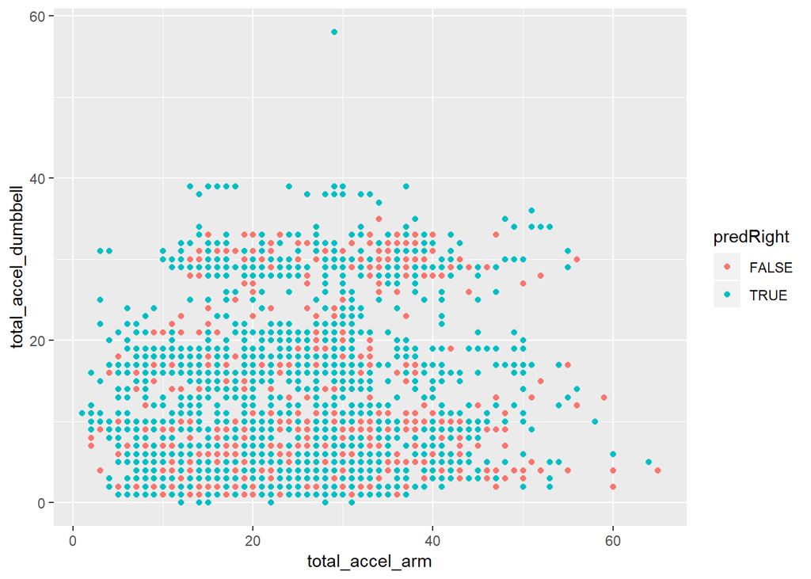

```r
testData1 <- testData
testData1$predRight <- pred01 == testData1$classe
qplot(total_accel_arm, total_accel_dumbbell, color = predRight, data = testData1)
```

# *3.3. Boosting model*

```r
set.seed(825)
mod02 <- train(classe ~ ., method = "gbm", data = trainData, verbose = FALSE)
```

```r
pred02 <- predict(mod02, newdata = testData)
confusionMatrix(data = pred02, reference = testData$classe)
```

```
## Confusion Matrix and Statistics
##
##           Reference
## Prediction    A    B    C    D    E
##          A 1082   33    0    1    2
##          B   24  688   42    4   11
##          C    8   35  621   38   18
##          D    2    1   19  597    9
##          E    0    2    2    3  681
##
## Overall Statistics
##
##                Accuracy : 0.9353
##                  95% CI : (0.9271, 0.9428)
##     No Information Rate : 0.2845
##     P-Value [Acc > NIR] : < 2.2e-16
##
##                   Kappa : 0.9181
##
##  Mcnemar's Test P-Value : 5.972e-06
##
## Statistics by Class:
##
##                      Class: A Class: B Class: C Class: D Class: E
## Sensitivity            0.9695   0.9065   0.9079   0.9285   0.9445
## Specificity            0.9872   0.9744   0.9694   0.9905   0.9978
## Pos Pred Value         0.9678   0.8947   0.8625   0.9506   0.9898
## Neg Pred Value         0.9879   0.9775   0.9803   0.9860   0.9876
## Prevalence             0.2845   0.1935   0.1744   0.1639   0.1838
## Detection Rate         0.2758   0.1754   0.1583   0.1522   0.1736
## Detection Prevalence   0.2850   0.1960   0.1835   0.1601   0.1754
## Balanced Accuracy      0.9784   0.9404   0.9387   0.9595   0.9712
```

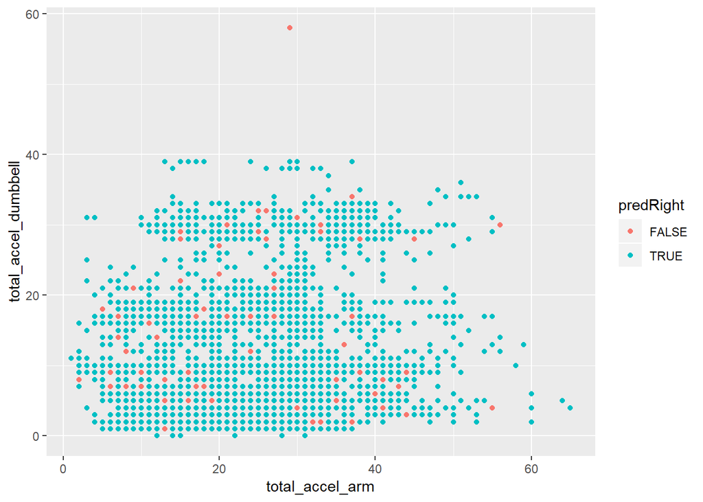

```r
testData1 <- testData
testData1$predRight <- pred02 == testData1$classe
qplot(total_accel_arm, total_accel_dumbbell, color = predRight, data = testData1)
```

# 4. Prediction for testing dataset

```r
PredTree <- predict(mod01, newdata = testing)
PredBoosting <- predict(mod02, newdata = testing)
data.frame(PredTree, PredBoosting)
```

```
##    PredTree PredBoosting
## 1         C            C
## 2         A            A
## 3         A            B
## 4         C            A
## 5         A            A
## 6         D            E
## 7         C            D
## 8         D            B
## 9         A            A
## 10        A            A
## 11        D            B
## 12        C            C
## 13        B            B
## 14        A            A
## 15        C            E
## 16        A            E
## 17        A            A
## 18        D            B
## 19        A            B
## 20        B            B
```